# Cerag Oguztuzun: Lab 05 for 431

Cerag Oguztuzun

2021-10-21

## Setup

```r
library(knitr)
library(palmerpenguins)
library(janitor)
library(broom)
library(magrittr)
library(naniar)
library(tidyverse)
```

## Import the `lab05_counties.csv` data

```r
lab05_data <- read_csv("data/lab05_counties.csv", show_col_types = FALSE)
summary(lab05_data)
```

```
    state                fips       county_name
 Length:3142        Min.   : 1001   Length:3142
 Class :character   1st Qu.:18178   Class :character
 Mode  :character   Median :29176   Mode  :character
                    Mean   :30384
                    3rd Qu.:45081
                    Max.   :56045

 adult_smoking    adult_obesity     teen_births     flu_vaccinations
 Min.   :0.0710   Min.   :0.1100   Min.   : 2.099   Min.   :0.0400
 1st Qu.:0.1860   1st Qu.:0.2960   1st Qu.:18.024   1st Qu.:0.3700
 Median :0.2110   Median :0.3380   Median :26.456   Median :0.4500
 Mean   :0.2132   Mean   :0.3345   Mean   :27.947   Mean   :0.4308
 3rd Qu.:0.2400   3rd Qu.:0.3740   3rd Qu.:36.443   3rd Qu.:0.5000
 Max.   :0.4460   Max.   :0.5890   Max.   :97.272   Max.   :0.6700
                                   NA's   :173      NA's   :18
  some_college    life_expectancy  food_insecurity uninsured_children
 Min.   :0.0080   Min.   : 64.41   Min.   :0.036   Min.   :0.00800
 1st Qu.:0.4990   1st Qu.: 75.54   1st Qu.:0.106   1st Qu.:0.03800
 Median :0.5820   Median : 77.53   Median :0.130   Median :0.05300
 Mean   :0.5813   Mean   : 77.51   Mean   :0.132   Mean   :0.06211
 3rd Qu.:0.6660   3rd Qu.: 79.44   3rd Qu.:0.156   3rd Qu.:0.07800
 Max.   :1.0000   Max.   :113.46   Max.   :0.304   Max.   :0.27500
                  NA's   :69                       NA's   :1
     metro        access_to_exercise_opportunities
 Min.   :0.0000   Min.   :0.0000
 1st Qu.:0.0000   1st Qu.:0.4852
 Median :0.0000   Median :0.6582
 Mean   :0.3713   Mean   :0.6281
 3rd Qu.:1.0000   3rd Qu.:0.8006
 Max.   :1.0000   Max.   :1.0000
 NA's   :2        NA's   :12
```

```r
nrow(lab05_data)
```

```
[1] 3142
```

# PART A

I used pipe to get the original dataset (lab05_data) and use the filter function on it which returns the data within the original dataset which qualify the condition of belonging to either states of Ohio (OH), Indiana (IN), Illinois (IL), Michigan (MI), and Wisconsin (WI).

Hence, the resulting dataset is put into a new variable called `midwest05` which have only the data where the state variable is OH or IN or IL or MI or WI.

```r
midwest05 <- lab05_data %>% filter(state == 'OH' | state == 'IN' | state == 'IL' | state == 'MI' | state == 'WI')
```

I used the select function to display the `state`, `county_name`, `metro` and `access_to_exercise_opportunities` values for the filtered result.

```r
midwest05 <- midwest05 %>% select(state, county_name, metro, access_to_exercise_opportunities)
```

Checking if each of the four variables we selected (`state`, `county_name`, `metro`, `access_to_exercise_opportunities`) has missing data for the counties in each state (Ohio (OH), Indiana (IN), Illinois (IL), Michigan (MI), and Wisconsin (WI)) I plan to study. It can be seen that there are no missing values. So, we can continue with the project.

```r
midwest05 %>%
    miss_var_summary()
```

```
# A tibble: 4 x 3
  variable                         n_miss pct_miss
  <chr>                             <int>    <dbl>
1 state                                 0        0
2 county_name                           0        0
3 metro                                 0        0
4 access_to_exercise_opportunities      0        0
```

# Question 1

The variable `access_to_exercise_opportunities` is changed to `exercise_access_percentage` for increased understandability and readability. The `exercise_access_percentage` variable values are converted to percentages that were previously valued between 0 and 1. The categorical variables `state` and `metro` are converted to Factor. Lastly, I printed the structure of my tibble to check the result of my work.

```r
midwest05 <- midwest05 %>%
    mutate(state = factor(state)) %>%
    mutate(metro = factor(metro)) %>%
    rename(exercise_access_percentage = access_to_exercise_opportunities) %>%
    mutate(exercise_access_percentage = 100*exercise_access_percentage) %>%
    mutate(metro = fct_recode(metro,
                              metropolitan = "1",
                              non_metropolitan = "0"))
str(midwest05)
```

```
tibble [437 x 4] (S3: tbl_df/tbl/data.frame)
 $ state                     : Factor w/ 5 levels "IL","IN","MI",..: 1 1 1 1 1 1 1 1 1 1 ...
 $ county_name               : chr [1:437] "Adams County" "Alexander County" "Bond County" "Boone County" ...
 $ metro                     : Factor w/ 2 levels "non_metropolitan",..: 1 2 2 2 1 1 2 1 1 2 ...
 $ exercise_access_percentage: num [1:437] 81.9 58.4 62.7 88.8 75.7 ...
```

I created a plot which compares the densities of non-metropolitan and metropolitan counties’ percent of adults with adequate exercise opportunities. It can be seen that, both densities are left-skewed, but density of percent of adults with adequate exercise opportunities in metropolitan counties are more skewed to the left. This suggests that the mean is smaller than the median for both metropolitan and non metropolitan counties, but median for metropolitan counties are higher. The first result derived is that **More adults in metropolitan counties have adequate access to exercise opportunities than the adults in non-metropolitan counties.**

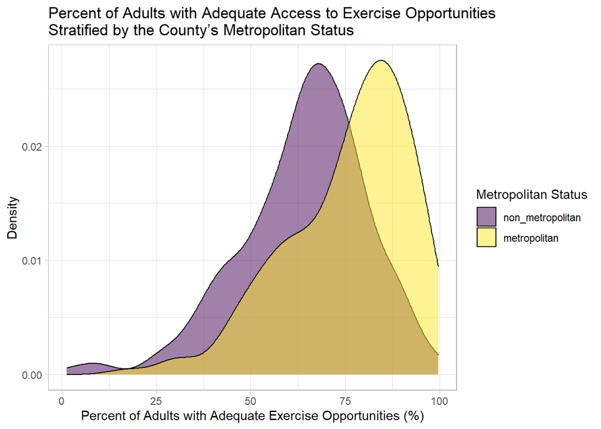

```r
midwest05 %>%
  ggplot(data = ., aes(x = exercise_access_percentage, fill = factor(metro))) +
  geom_density(alpha = 0.5) +
  scale_fill_viridis_d() +
  theme_light() +
  labs(fill = 'Metropolitan Status', title = "Percent of Adults with Adequate Access to Exercise Opportunities \nStratified by the County’s Metropolitan Status", x = "Percent of Adults with Adequate Exercise Opportunities (%)", y = "Density")
```

# Question 2

The sampling approach used in Question 1 was filtering the whole `lab05_counties.csv` dataset to the five states (Ohio (OH), Indiana (IN), Illinois (IL), Michigan (MI), and Wisconsin (WI)). Hence, every row in `lab05_counties.csv` which has one of the specified states are included in the sample, which results in the `midwest05` dataset. So, this sampling approach is not random, but the whole data the dataset consist that has the specifies states. This is because the analysis is going to be done on the specified states and examining the relationship between the percent of adults with adequate exercise opportunities regarding whether the county is metropolitan or not. The data is from County Health Rankings which should be enough to gain a conclusion within the specified states at least.

# Question 3

The data developed in Question 1 consists of **independent samples**. Because, the samples consist of the `metro` variable of distinct states such that different groups of cases for each county in a state are compared for the same variable `exercise_access_percentage`. However, paired samples compare connected values of groups. Also, we cannot pair a metro or non-metro state with any particular value for `exercise_access_percentage`. Hence, It is an independent sample.

# Question 4

A plot is generated where distributions of each metro or non-metro state regarding `exercise_access_percentage` densities are shown separately, the means for each distribution are marked by a red diamond. From the plot, It can be seen that the distributions are all left-skewed but the means are not very similar.

Metropolitan states has the highest mean of `exercise_access_percentage` distribution. For inferential procedures, we could create a confidence interval by comparing population means of each state through a bootstrap approach. The distributions do not have equal variances, and are not normally distributed as they have skew, hence I can’t use a t-test approach. So, I will use a regression model approach with a single predictor.

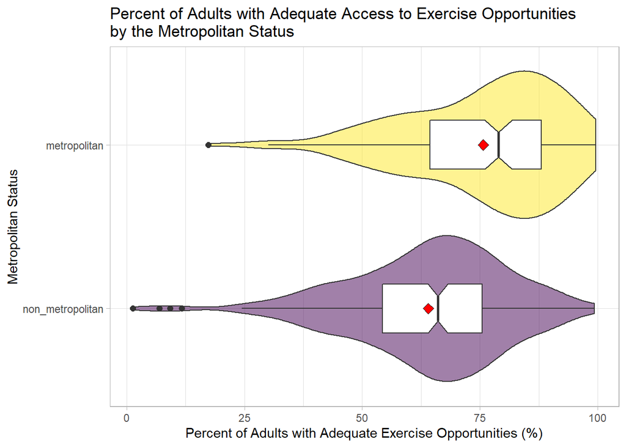

```r
ggplot(midwest05, aes(x = metro, y = exercise_access_percentage)) +
  geom_violin(aes(fill = metro)) +
  geom_boxplot(width = 0.3, outlier.size = 2, notch = T) +
  stat_summary(fun = 'mean', geom = 'point', shape = 23, size = 3, fill = 'red') +
  guides(fill = 'none') +
  scale_fill_viridis_d(alpha = 0.5) +
  theme_light() +
  coord_flip() +
  labs(title = "Percent of Adults with Adequate Access to Exercise Opportunities \nby the Metropolitan Status", y = "Percent of Adults with Adequate Exercise Opportunities (%)", x = "Metropolitan Status")
```

# Question 5

```r
regmodel <- lm(exercise_access_percentage ~ metro, data = midwest05)

tidy(regmodel, conf.int = TRUE, conf.level = 0.95) %>%
    kable(digits = 3)
```

| term | estimate | std.error | statistic | p.value | conf.low | conf.high |
| --- | --- | --- | --- | --- | --- | --- |
| (Intercept) | 64.052 | 1.018 | 62.893 | 0 | 62.05 | 66.053 |
| metrometropolitan | 11.673 | 1.614 | 7.232 | 0 | 8.50 | 14.845 |

# Question 6

The `exercise_access_percentage ~ metro` population mean difference is estimated as 11.673% of adults with access to exercise opportunities, with the 95% confidence internal which is (8.50, 14.845) percent. So, there is a 11.673% of mean percentage difference of adults with access to exercise opportunities between metropolitan and non-metropolitan counties within 5 selected states. The range of values with 95% confidence that the distribution contains is (8.50, 14.845) percent.

# Question 7

```r
lab05_lind_data <- readRDS("data/lab05_lind.Rds")
summary(lab05_lind_data)
```

```
    lifepres       cardbill          abcix            stent
 Min.   : 0.0   Min.   :  2216   Min.   :0.0000   Min.   :0.0000
 1st Qu.:11.6   1st Qu.: 10219   1st Qu.:0.0000   1st Qu.:0.0000
 Median :11.6   Median : 12458   Median :1.0000   Median :1.0000
 Mean   :11.3   Mean   : 15674   Mean   :0.7008   Mean   :0.6687
 3rd Qu.:11.6   3rd Qu.: 16660   3rd Qu.:1.0000   3rd Qu.:1.0000
 Max.   :11.6   Max.   :178534   Max.   :1.0000   Max.   :1.0000
     height          female          diabetic         acutemi
 Min.   :108.0   Min.   :0.0000   Min.   :0.0000   Min.   :0.0000
 1st Qu.:165.0   1st Qu.:0.0000   1st Qu.:0.0000   1st Qu.:0.0000
 Median :173.0   Median :0.0000   Median :0.0000   Median :0.0000
 Mean   :171.4   Mean   :0.3474   Mean   :0.2239   Mean   :0.1436
 3rd Qu.:178.0   3rd Qu.:1.0000   3rd Qu.:0.0000   3rd Qu.:0.0000
 Max.   :196.0   Max.   :1.0000   Max.   :1.0000   Max.   :1.0000
    ejecfrac        ves1proc     sixMonthSurvive
 Min.   : 0.00   Min.   :0.000   Mode :logical
 1st Qu.:45.00   1st Qu.:1.000   FALSE:26
 Median :55.00   Median :1.000   TRUE :970
 Mean   :50.97   Mean   :1.386
 3rd Qu.:56.00   3rd Qu.:2.000
 Max.   :90.00   Max.   :5.000
```

```r
nrow(lab05_lind_data)
```

```
[1] 996
```

I converted types some of the variables which make sense If they were factors which are: `abcix`, `stent`, `female`, `diabetic` and `acutemi`. I renamed them and their factor values as more meaningful names.

```r
lab05_lind_data <- lab05_lind_data %>%
    mutate(abcix = factor(abcix)) %>%
    mutate(abcix = fct_recode(abcix,
                              PCI_with_abciximab = "1",
                              only_usual_PCI_care = "0")) %>%
    rename(treatment_selection_indicator = abcix) %>%

    mutate(stent = factor(stent)) %>%
    mutate(stent = fct_recode(stent,
                              yes = "1",
                              no = "0")) %>%
    rename(coronary_stent_deployment = stent) %>%

    mutate(female = factor(female)) %>%
    mutate(female = fct_recode(female,
                              yes = "1",
                              no = "0")) %>%

    mutate(diabetic = factor(diabetic)) %>%
    mutate(diabetic = fct_recode(diabetic,
                              diagnosed_diabetic = "1",
                              not_diagnosed_diabetic = "0")) %>%

    mutate(acutemi = factor(acutemi)) %>%
    mutate(acutemi = fct_recode(acutemi,
                              yes = "1",
                              no = "0")) %>%
    rename(acute_myocardial_infarction = acutemi)


str(lab05_lind_data)
```

```
tibble [996 x 11] (S3: tbl_df/tbl/data.frame)
 $ lifepres                     : num [1:996] 0 11.6 11.6 11.6 11.6 11.6 11.6 11.6 11.6 11.6 ...
 $ cardbill                     : int [1:996] 14301 3563 4694 7366 8247 8319 8410 8517 8763 8823 ...
 $ treatment_selection_indicator: Factor w/ 2 levels "only_usual_PCI_care",..: 2 2 2 2 2 2 2 2 2 2 ...
 $ coronary_stent_deployment    : Factor w/ 2 levels "no","yes": 1 1 1 1 1 1 1 1 1 1 ...
 $ height                       : int [1:996] 163 168 188 175 168 178 185 173 152 180 ...
 $ female                       : Factor w/ 2 levels "no","yes": 2 1 1 1 2 1 1 2 2 1 ...
 $ diabetic                     : Factor w/ 2 levels "not_diagnosed_diabetic",..: 2 1 1 2 1 1 1 1 1 1 ...
 $ acute_myocardial_infarction  : Factor w/ 2 levels "no","yes": 1 1 1 1 1 1 1 1 1 1 ...
 $ ejecfrac                     : int [1:996] 56 56 50 50 55 50 58 30 60 60 ...
 $ ves1proc                     : int [1:996] 1 1 1 1 1 1 1 1 1 1 ...
 $ sixMonthSurvive              : logi [1:996] FALSE TRUE TRUE TRUE TRUE TRUE ...
```

The `treatment_selection_indicator` and `acutemi` are paired values, as their values depend on each others’ calculation. Hence, I built a 90% two-sided confidence interval regarding the population mean differences of relative risk of an `acutemi` for those receiving `abciximab` compared to those receiving usual care. The confidence interval is (1.68, 1.72), meaning It is the population mean difference between those receiving `abciximab` compared to those receiving usual care by the t-test.

```r
tt1 <- lab05_lind_data %$% t.test(as.numeric(treatment_selection_indicator), conf.level = 0.90,
                            alt = "two.sided")

tidy(tt1) %>% knitr::kable(digits = 2)
```

| estimate | statistic | p.value | parameter | conf.low | conf.high | method | alternative |
| --- | --- | --- | --- | --- | --- | --- | --- |
| 1.7 | 117.16 | 0 | 995 | 1.68 | 1.72 | One Sample t-test | two.sided |

# Question 8

```r
tt1 <- lab05_lind_data %$% t.test(as.numeric(diabetic), conf.level = 0.90,
                            alt = "two.sided")

tidy(tt1) %>% knitr::kable(digits = 2)
```

| estimate | statistic | p.value | parameter | conf.low | conf.high | method | alternative |
| --- | --- | --- | --- | --- | --- | --- | --- |
| 1.22 | 92.61 | 0 | 995 | 1.2 | 1.25 | One Sample t-test | two.sided |

# Question 9

- 405 were predicted to survive at least 6 months, and actually survived at least 6 months

The value 405 indicates the True Positives (`TP`) for the model.

- 74 were predicted not to survive at least 6 months, but did actually survive at least 6 months

The value 74 indicates the False Negatives (`FN`) for the model.

- 9 were predicted not to survive at least 6 months and did not actually survive at least 6 months.

The value 9 indicates the True Negatives (`TN`) for the model.

495 - ( 405 + 74 + 9 ) = 7 is the resulting False Positives (`FP`) such that 7 were predicted to survive at least 6 months and did not actually survive at least 6 months.

[output not shown]

Accuracy is ( TP + TN ) / ( TP + TN + FP + FN ) = 0.83

Sensitivity is ( TP ) / ( TP + FN ) = 0.84

Specificity is ( TN ) / ( TN + FP ) = 0.56